# Time dependent Cox

J.S. González-Martínez

2021-09-03

##### Below are the results for the second series of Cox proportional hazard analyses. The analyses below treat covariates as time-dependent. We developed univariate and multivariate models.

##### **Libraries required**

```r
library(readr)
library(tidyverse)
library(lubridate)
library(plyr)
library(dplyr)
library(survival)
library(survminer)
```

##### **Upload data**

```r
all_df <- read.csv("all_merged.csv")

all_df <- all_df[,-1]
```

##### **Further data processing: Calculate time intervals required for analyses**

```r
#verify no observations have a time of observation greater than overall time of survival
nrow(filter(all_df, time_survob > time_surv))
```

```
## [1] 0
```

```r
#reorder df so time intervals are ordered by ID and time_survob is ordered in descending order within ID clusters

all_df <- all_df[with(all_df, order(brc_id, -time_survob)),]

#calculate time 1

all_df <- all_df %>%
  dplyr::mutate(time1 = time_surv - time_survob)

#reorder df so time intervals are ordered by ID and time1 is ordered in ascending order within ID clusters

all_df <- all_df[with(all_df, order(brc_id, time1)),]

#calculate time2

all_df <- all_df %>%
  group_by(brc_id) %>%
  mutate(time2 = lead(time1, default = 0))

#screen observations where time1 > time 2 - which will need to be removed because the model will see them as illogical

compare0 <- filter(all_df, time1 > time2) %>%
  dplyr::select(brc_id, obsv_id, min_dateobsv, max_dateobsv, date_entry, time_surv, time_survob, time1, time2)

head(compare0, 10)[,-1:-2] #index printing so patient IDs are not printed and time2 shows in html file
```

```
## # A tibble: 10 x 7
##    min_dateobsv max_dateobsv date_entry time_surv time_survob time1 time2
##    <chr>        <chr>        <chr>          <int>       <int> <int> <dbl>
##  1 2016-05-26   2016-05-26   2011-06-29      1793           0  1793     0
##  2 2015-07-28   2015-07-28   2014-03-03       512           0   512     0
##  3 2015-03-23   2015-03-23   2010-12-30      1544           0  1544     0
##  4 2014-06-25   2014-06-25   2013-11-13       224           0   224     0
##  5 2016-09-05   2016-09-05   2016-05-16       112           0   112     0
##  6 2018-01-22   2018-01-22   2017-08-31       144           0   144     0
##  7 2016-01-14   2016-01-14   2013-07-11       917           0   917     0
##  8 2014-05-08   2014-05-09   2014-05-08         1           0     1     0
##  9 2017-05-22   2017-05-22   2015-11-03       566           0   566     0
## 10 2012-06-27   2012-06-27   2012-03-14       105           0   105     0
```

```r
#it seems these are observations where time2 = 0, i.e., patents' have no more time of survival remaining

all_df <- all_df %>% #remove those observation where time2 = 0
  filter(time2 != 0)

#recall_df where time1 > time 2
compare1 <- filter(all_df, time1 > time2) %>%
  dplyr::select(brc_id, obsv_id, min_dateobsv, max_dateobsv, date_entry, time_surv, time_survob, time1, time2)

nrow(compare1) #returns no observations
```

```
## [1] 0
```

##### **Establish patients’ characteristics for analysis**

```r
#develop a function to obtain quick frequency tables percentages

freq_per_info <- function(var) {#function to generate a table with frequencies and percentages
  library(epiDisplay) #library required
  tab1(var,
       sort.group = "decreasing",
       cum.percentage = T,
       graph = F)}
```

Create subsets of data to find patient characteristics.

```r
freq_df0 <- all_df %>%
  group_by(brc_id, Gender_Value, Ethnicity_Value, marital_status, cause_diagper, age_diag, age_entry, time_surv) %>%
  dplyr::summarise(n = n())

#calculate mean, median, and standard deviation for continuous parables

#age of entry
summary(freq_df0$age_entry)
```

```
##    Min. 1st Qu.  Median    Mean 3rd Qu.    Max.
##   50.67   76.26   82.03   81.19   86.72  105.08
```

```r
sd(freq_df0$age_entry)
```

```
## [1] 7.699779
```

```r
#age of diagnosis
summary(freq_df0$age_diag)
```

```
##    Min. 1st Qu.  Median    Mean 3rd Qu.    Max.
##   50.67   76.19   82.05   81.18   86.75  105.02
```

```r
sd(freq_df0$age_diag)
```

```
## [1] 7.73159
```

```r
#time of survival
summary(freq_df0$time_surv)
```

```
##    Min. 1st Qu.  Median    Mean 3rd Qu.    Max.
##     1.0    85.0   258.0   476.4   714.0  5728.0
```

```r
sd(freq_df0$time_surv)
```

```
## [1] 539.5939
```

```r
#calculate frequencies and percentages for categorical variables

#gender
freq_per_info(freq_df0$Gender_Value)
```

```
## var :
##         Frequency Percent Cum. percent
## Female       5992    60.4         60.4
## Male         3921    39.6        100.0
##   Total      9913   100.0        100.0
```

```r
#ethnicity
freq_per_info(freq_df0$Ethnicity_Value)
```

```
## var :
##         Frequency   %(NA+)   %(NA-)
## White        6248     63.0     97.4
## <NA>         3498     35.3      0.0
## Asian          74      0.7      1.2
## Other          60      0.6      0.9
## Black          33      0.3      0.5
##   Total      9913    100.0    100.0
```

```r
#marital status
freq_per_info(freq_df0$marital_status)
```

```
## var :
##                    Frequency   %(NA+)   %(NA-)
## <NA>                    4625     46.7      0.0
## Any union               2717     27.4     51.4
## Widowed                 1972     19.9     37.3
## Single                   339      3.4      6.4
## Divorced/Separated       260      2.6      4.9
##   Total                 9913    100.0    100.0
```

```r
#initial cause (i.e., type of dementia)
freq_per_info(freq_df0$cause_diagper)
```

```
## var :
##             Frequency Percent Cum. percent
## Unspecified      5904    59.6         59.6
## AD               3077    31.0         90.6
## VaD               574     5.8         96.4
## DLB               177     1.8         98.2
## MixedADVaD        104     1.0         99.2
## FTD                58     0.6         99.8
## PPD                19     0.2        100.0
##   Total          9913   100.0        100.0
```

```r
#create a separate data frames for variables for which patients could have been in more than one group

#medication exposure
freq_df1 <- all_df %>%
  group_by(brc_id, med_exposure) %>%
  dplyr::summarise(n = n())

#run frequencies for medication exposure
freq_per_info(freq_df1$med_exposure)
```

```
## var :
##           Frequency Percent Cum. percent
## exposed        6389    57.5         57.5
## unexposed      4716    42.5        100.0
##   Total       11105   100.0        100.0
```

```r
#type of dementia medication and medication class

freq_df2 <- all_df %>%
  group_by(brc_id, type_med, type_medclass) %>%
  dplyr::summarise(n = n())

#run frequencies for type of dementia medication

freq_per_info(freq_df2$type_med)
```

```
## var :
##              Frequency   %(NA+)   %(NA-)
## <NA>              5642     37.7      0.0
## Donepezil         4571     30.6     49.1
## AChEi             2092     14.0     22.5
## Mementine         1276      8.5     13.7
## Rivastigmine       896      6.0      9.6
## Galantamine        477      3.2      5.1
##   Total          14954    100.0    100.0
```

```r
#run frequencies for dementia medication class

freq_per_info(freq_df2$type_medclass)
```

```
## var :
##           Frequency   %(NA+)   %(NA-)
## Any AChEi      8036     53.7     86.3
## <NA>           5642     37.7      0.0
## Mementine      1276      8.5     13.7
##   Total       14954    100.0    100.0
```

```r
#types of chronic medication types

freq_df3 <- all_df %>%
  group_by(brc_id, medother_grouped) %>%
  dplyr::summarise(n = n())

#run frequencies for chronic medication types

freq_per_info(freq_df3$medother_grouped)
```

```
## var :
##                Frequency   %(NA+)   %(NA-)
## <NA>                9379     69.2      0.0
## SSRIs               1275      9.4     30.6
## Antipsychotics       968      7.1     23.2
## Trazodone            846      6.2     20.3
## TeCAs                609      4.5     14.6
## TCAs                 197      1.5      4.7
## Insulin              159      1.2      3.8
## SNRIs                112      0.8      2.7
##   Total            13545    100.0    100.0
```

```r
#patient distribution of cognitive assessments

freq_df4 <- all_df %>%
  group_by(brc_id, type_cogeval ) %>%
  filter(!is.na(type_cogeval)) %>%
  dplyr::summarise(n = n())

#run frequencies for distribution of cognitive assessments
freq_per_info(freq_df4$type_cogeval)
```

```
## var :
##         Frequency Percent Cum. percent
## MMSE         4912    57.1         57.1
## MOCA         3688    42.9        100.0
##   Total      8600   100.0        100.0
```

```r
#number of assessments administered

freq_df5 <- all_df %>%
  group_by(type_cogeval) %>%
  filter(!is.na(type_cogeval))

freq_per_info(freq_df5$type_cogeval)
```

```
## var :
##         Frequency Percent Cum. percent
## MMSE        14088    59.2         59.2
## MOCA         9709    40.8        100.0
##   Total     23797   100.0        100.0
```

```r
#calculate mean, median, and standard deviation of all cognitive assessment scores

summary(freq_df5$numerator)
```

```
##    Min. 1st Qu.  Median    Mean 3rd Qu.    Max.
##    1.00   14.00   20.00   18.78   24.00   30.00
```

```r
sd(freq_df5$numerator)
```

```
## [1] 7.037049
```

```r
#calculate mean, median, and standard deviation per type of cognitive assessment

freq_df6 <- freq_df5 %>%
  dplyr::summarise_at(vars(numerator), list( "count" = ~ n(),
                                            "mean" = mean,
                                            "median" = median,
                                            "stdv" = sd))
freq_df6
```

```
## # A tibble: 2 x 5
##   type_cogeval count  mean median  stdv
##   <chr>        <int> <dbl>  <dbl> <dbl>
## 1 MMSE         14088  20.6     22  6.32
## 2 MOCA          9709  16.1     17  7.18
```

##### Establish death event rules

Censor data based on time intervals

Rules:

1. Check the last time interval per patient (i.e., when time_surv = time 2)
2. If there is a date of death recorded for that patient, and that date of death was before the cohort’s end span (“2019-05-01”), then the interval corresponds to a death within the study period
3. All other observations shall be censored

```r
all_df <- all_df %>%
   dplyr::mutate(event_death = ifelse((time_surv == time2) & !is.na(Date_Of_Death) &
                                      (Date_Of_Death  <= "2019-05-01"), 1, 0)) %>%
   dplyr::mutate(event_death = as.numeric(event_death))

table(all_df$event_death)
```

```
##
##     0     1
## 53828  5145
```

##### **Univariate models**

Functionalise graph plotting

```r
#function to customise plot of Schoenfeld's test results

plot_schoenfeld <- function(resx, var_name) {
  my_plot0 <- ggcoxzph(resx,
                       title = print(paste("Schoenfeld's test results for", var_name)),
                       xlab = "Time (days)",
                       ylab = print(paste("Beta(t) for", var_name)))

  return(my_plot0)}

#function to customise plots of survival curves (only works for continuous variables)

plot_surv <- function(fitobj, var_name, namesobj) {
 my_plot1 <- ggsurvplot(fitobj, #default
           palette = "nejm", #default
           censor.size = 2, #default
           title = print("Survival probablity in OxNHS dementia patients"),
           subtitle = print(paste("Adjusted for", var_name, "(time-dependent analysis)")),
           font.subtitle = c(14, "italic"),
           xlab = "Time (days)", #default
           legend.title = str_to_title(var_name),
           legend.labs = namesobj)

  return(my_plot1)}
```

##### Start univariate model fitting

**Gender**

```r
cox0 <- coxph(Surv(time1, time2, event_death) ~ Gender_Value, data = all_df) #fit model

summary(cox0) #print results
```

```
## Call:
## coxph(formula = Surv(time1, time2, event_death) ~ Gender_Value,
##     data = all_df)
##
##   n= 58973, number of events= 5145
##
##                     coef exp(coef) se(coef)     z Pr(>|z|)
## Gender_ValueMale 0.04715   1.04828  0.02837 1.662   0.0965 .
## ---
## Signif. codes:  0 '***' 0.001 '**' 0.01 '*' 0.05 '.' 0.1 ' ' 1
##
##                  exp(coef) exp(-coef) lower .95 upper .95
## Gender_ValueMale     1.048     0.9539    0.9916     1.108
##
## Concordance= 0.504  (se = 0.004 )
## Likelihood ratio test= 2.75  on 1 df,   p=0.1
## Wald test            = 2.76  on 1 df,   p=0.1
## Score (logrank) test = 2.76  on 1 df,   p=0.1
```

```r
cox.zph(cox0) #print Schoenfeld's test results
```

```
##              chisq df    p
## Gender_Value 0.467  1 0.49
## GLOBAL       0.467  1 0.49
```

```
## [1] "Schoenfeld's test results for gender"
## [1] "Beta(t) for gender"
```

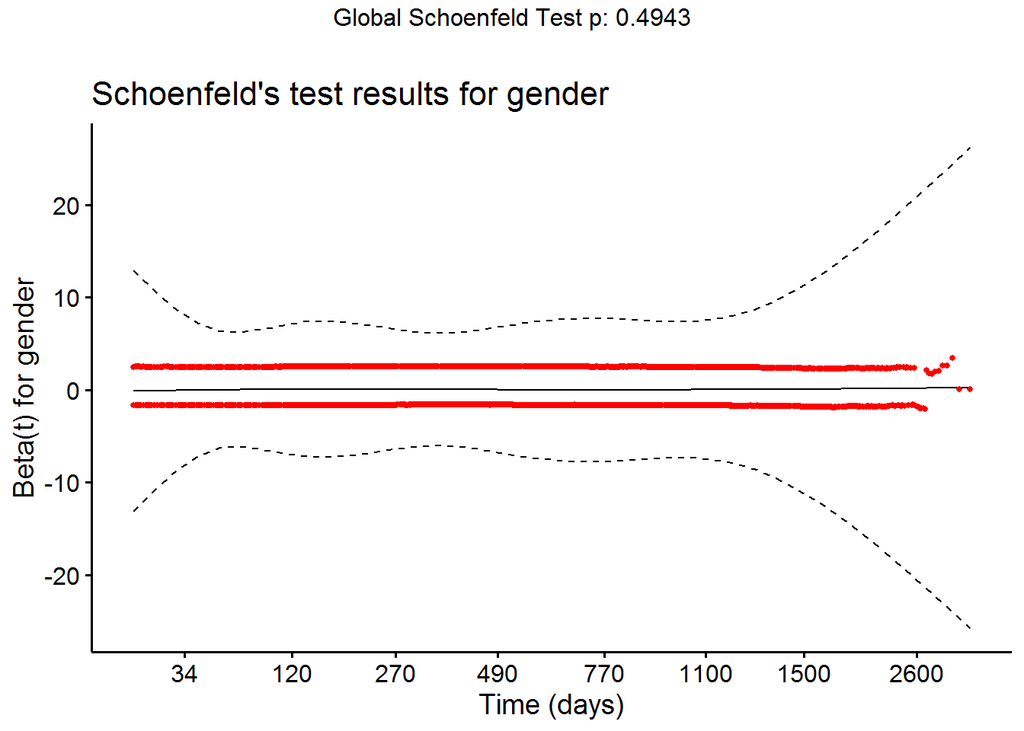

```r
res0 <- cox.zph(cox0) #store Schoenfeld's test results

plot_schoenfeld(res0, "gender") #plot Schoenfeld's test
```

```
## [1] "Survival probablity in OxNHS dementia patients"
## [1] "Adjusted for gender (time-dependent analysis)"
```

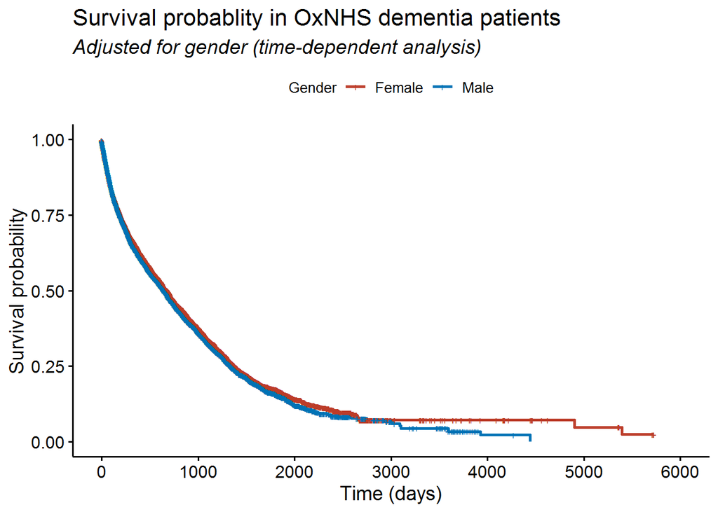

```r
fit0 <- survfit(Surv(time1, time2, event_death) ~ Gender_Value, data = all_df)

plot_surv(fit0, "gender", c("Female", "Male")) #plot survival curve
```

```r
anova(cox0) #ANOVA log likelihood test to determine whether fitted model is significantly better than a no-model solution
```

```
## Analysis of Deviance Table
##  Cox model: response is Surv(time1, time2, event_death)
## Terms added sequentially (first to last)
##
##              loglik  Chisq Df Pr(>|Chi|)
## NULL         -42295
## Gender_Value -42294 2.7536  1    0.09703 .
## ---
## Signif. codes:  0 '***' 0.001 '**' 0.01 '*' 0.05 '.' 0.1 ' ' 1
```

Repeat for all other covariates of interest. Survival curves are only plotted for categorical covariates.

**Age of entry**

```r
cox1 <- coxph(Surv(time1, time2, event_death) ~ age_entry, data = all_df)

summary(cox1)
```

```
## Call:
## coxph(formula = Surv(time1, time2, event_death) ~ age_entry,
##     data = all_df)
##
##   n= 58973, number of events= 5145
##
##               coef exp(coef) se(coef)    z Pr(>|z|)
## age_entry 0.074204  1.077027 0.002085 35.6   <2e-16 ***
## ---
## Signif. codes:  0 '***' 0.001 '**' 0.01 '*' 0.05 '.' 0.1 ' ' 1
##
##           exp(coef) exp(-coef) lower .95 upper .95
## age_entry     1.077     0.9285     1.073     1.081
##
## Concordance= 0.655  (se = 0.004 )
## Likelihood ratio test= 1388  on 1 df,   p=<2e-16
## Wald test            = 1267  on 1 df,   p=<2e-16
## Score (logrank) test = 1282  on 1 df,   p=<2e-16
```

```r
cox.zph(cox1)
```

```
##           chisq df       p
## age_entry  16.2  1 5.7e-05
## GLOBAL     16.2  1 5.7e-05
```

```
## [1] "Schoenfeld's test results for age of entry"
## [1] "Beta(t) for age of entry"
```

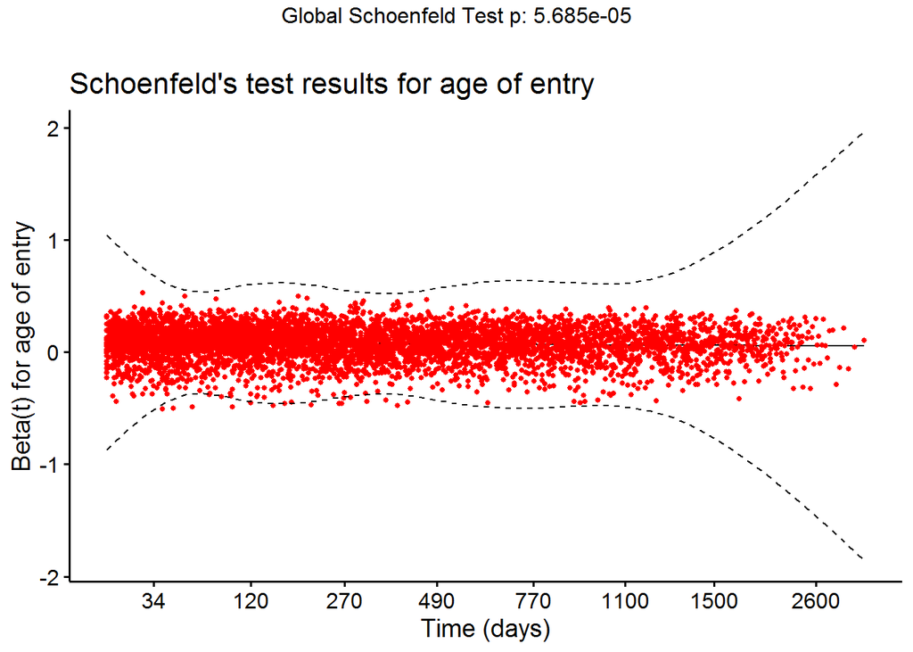

```r
res1 <- cox.zph(cox1)

plot_schoenfeld(res1, "age of entry")
```

```r
anova(cox1)
```

```
## Analysis of Deviance Table
##  Cox model: response is Surv(time1, time2, event_death)
## Terms added sequentially (first to last)
##
##           loglik  Chisq Df Pr(>|Chi|)
## NULL      -42295
## age_entry -41601 1388.2  1  < 2.2e-16 ***
## ---
## Signif. codes:  0 '***' 0.001 '**' 0.01 '*' 0.05 '.' 0.1 ' ' 1
```

**Age at observation**

```r
cox2 <- coxph(Surv(time1, time2, event_death) ~ age_obsv, data = all_df)

summary(cox2)
```

```
## Call:
## coxph(formula = Surv(time1, time2, event_death) ~ age_obsv, data = all_df)
##
##   n= 58973, number of events= 5145
##
##              coef exp(coef) se(coef)     z Pr(>|z|)
## age_obsv 0.079319  1.082550 0.002095 37.86   <2e-16 ***
## ---
## Signif. codes:  0 '***' 0.001 '**' 0.01 '*' 0.05 '.' 0.1 ' ' 1
##
##          exp(coef) exp(-coef) lower .95 upper .95
## age_obsv     1.083     0.9237     1.078     1.087
##
## Concordance= 0.659  (se = 0.004 )
## Likelihood ratio test= 1585  on 1 df,   p=<2e-16
## Wald test            = 1434  on 1 df,   p=<2e-16
## Score (logrank) test = 1450  on 1 df,   p=<2e-16
```

```r
cox.zph(cox2)
```

```
##          chisq df    p
## age_obsv  2.35  1 0.13
## GLOBAL    2.35  1 0.13
```

```
## [1] "Schoenfeld's test results for age at observation"
## [1] "Beta(t) for age at observation"
```

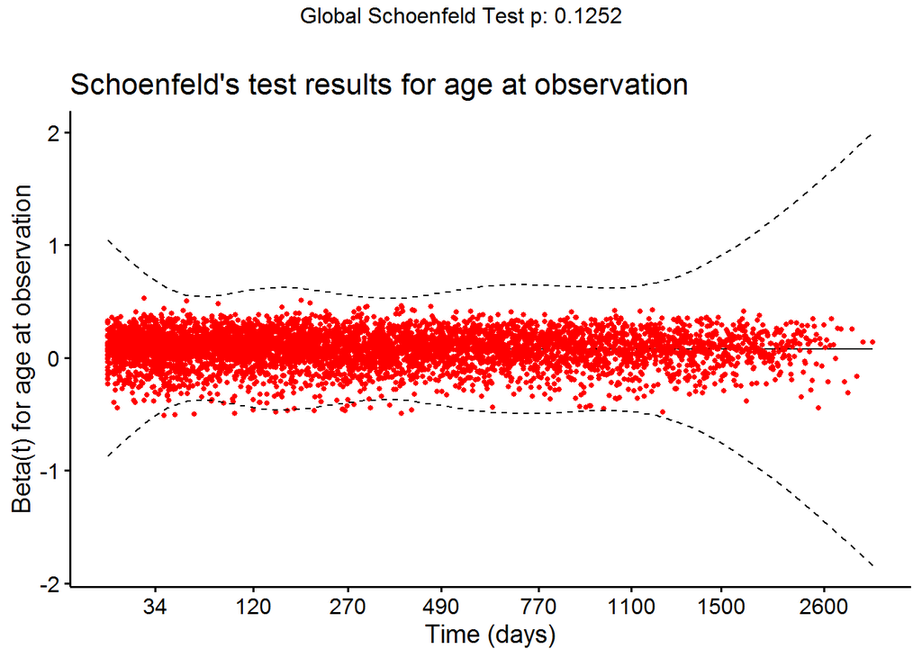

```r
res2 <- cox.zph(cox2)

plot_schoenfeld(res2, "age at observation")
```

```r
anova(cox2)
```

```
## Analysis of Deviance Table
##  Cox model: response is Surv(time1, time2, event_death)
## Terms added sequentially (first to last)
##
##          loglik  Chisq Df Pr(>|Chi|)
## NULL     -42295
## age_obsv -41503 1584.8  1  < 2.2e-16 ***
## ---
## Signif. codes:  0 '***' 0.001 '**' 0.01 '*' 0.05 '.' 0.1 ' ' 1
```

**Age of diagnosis**

```r
cox3 <- coxph(Surv(time1, time2, event_death) ~ age_diag, data = all_df)

summary(cox3)
```

```
## Call:
## coxph(formula = Surv(time1, time2, event_death) ~ age_diag, data = all_df)
##
##   n= 58973, number of events= 5145
##
##              coef exp(coef) se(coef)     z Pr(>|z|)
## age_diag 0.069294  1.071751 0.002032 34.11   <2e-16 ***
## ---
## Signif. codes:  0 '***' 0.001 '**' 0.01 '*' 0.05 '.' 0.1 ' ' 1
##
##          exp(coef) exp(-coef) lower .95 upper .95
## age_diag     1.072     0.9331     1.067     1.076
##
## Concordance= 0.65  (se = 0.005 )
## Likelihood ratio test= 1265  on 1 df,   p=<2e-16
## Wald test            = 1163  on 1 df,   p=<2e-16
## Score (logrank) test = 1176  on 1 df,   p=<2e-16
```

```r
cox.zph(cox3)
```

```
##          chisq df       p
## age_diag  23.7  1 1.1e-06
## GLOBAL    23.7  1 1.1e-06
```

```
## [1] "Schoenfeld's test results for age of diagnosis"
## [1] "Beta(t) for age of diagnosis"
```

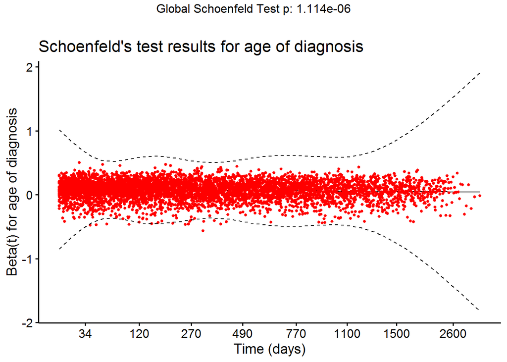

```r
res3 <- cox.zph(cox3)

plot_schoenfeld(res3, "age of diagnosis")
```

```r
anova(cox3)
```

```
## Analysis of Deviance Table
##  Cox model: response is Surv(time1, time2, event_death)
## Terms added sequentially (first to last)
##
##          loglik  Chisq Df Pr(>|Chi|)
## NULL     -42295
## age_diag -41663 1265.4  1  < 2.2e-16 ***
## ---
## Signif. codes:  0 '***' 0.001 '**' 0.01 '*' 0.05 '.' 0.1 ' ' 1
```

**Dementia medication exposure**

```r
table(all_df$med_exposure)
```

```
##
##   exposed unexposed
##     44230     14743
```

```r
cox4 <- coxph(Surv(time1, time2, event_death) ~ med_exposure, data = all_df)

summary(cox4)
```

```
## Call:
## coxph(formula = Surv(time1, time2, event_death) ~ med_exposure,
##     data = all_df)
##
##   n= 58973, number of events= 5145
##
##                          coef exp(coef) se(coef)     z Pr(>|z|)
## med_exposureunexposed 0.06291   1.06493  0.02914 2.159   0.0309 *
## ---
## Signif. codes:  0 '***' 0.001 '**' 0.01 '*' 0.05 '.' 0.1 ' ' 1
##
##                       exp(coef) exp(-coef) lower .95 upper .95
## med_exposureunexposed     1.065      0.939     1.006     1.128
##
## Concordance= 0.534  (se = 0.004 )
## Likelihood ratio test= 4.63  on 1 df,   p=0.03
## Wald test            = 4.66  on 1 df,   p=0.03
## Score (logrank) test = 4.66  on 1 df,   p=0.03
```

```r
cox.zph(cox4)
```

```
##              chisq df      p
## med_exposure   184  1 <2e-16
## GLOBAL         184  1 <2e-16
```

```
## [1] "Schoenfeld's test results for dementia medication exposure"
## [1] "Beta(t) for dementia medication exposure"
```

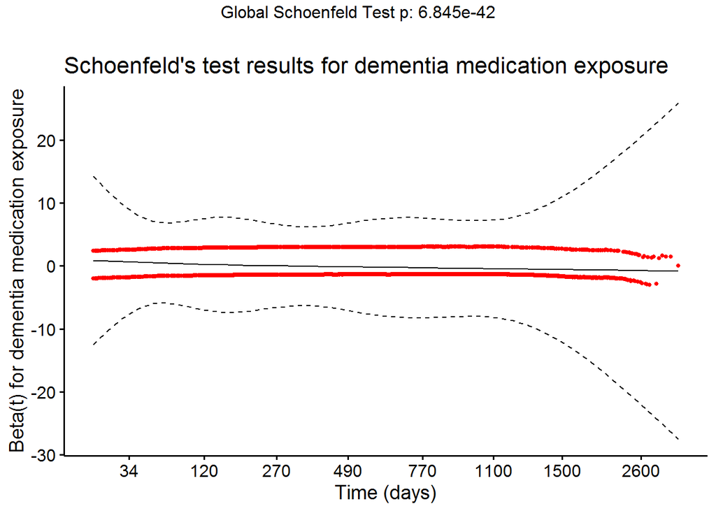

```r
res4 <- cox.zph(cox4)

plot_schoenfeld(res4, "dementia medication exposure")
```

```
## [1] "Survival probablity in OxNHS dementia patients"
## [1] "Adjusted for dementia medication exposure (time-dependent analysis)"
```

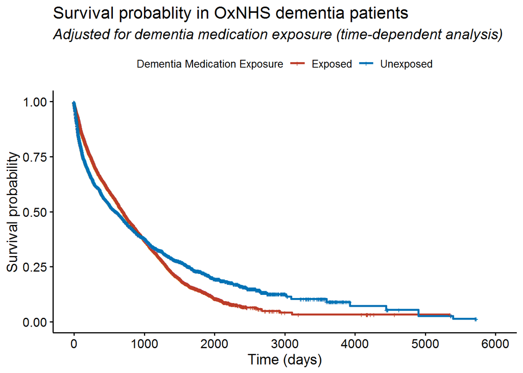

```r
fit4 <- survfit(Surv(time1, time2, event_death) ~ med_exposure, data = all_df)

plot_surv(fit4, "dementia medication exposure", c("Exposed", "Unexposed"))
```

```r
anova(cox4)
```

```
## Analysis of Deviance Table
##  Cox model: response is Surv(time1, time2, event_death)
## Terms added sequentially (first to last)
##
##              loglik  Chisq Df Pr(>|Chi|)
## NULL         -42295
## med_exposure -42293 4.6331  1    0.03136 *
## ---
## Signif. codes:  0 '***' 0.001 '**' 0.01 '*' 0.05 '.' 0.1 ' ' 1
```

**Initial dementia diagnosis**

```r
freq_per_info(all_df$cause_diagper)
```

```
## var :
##             Frequency Percent Cum. percent
## Unspecified     34054    57.7         57.7
## AD              19387    32.9         90.6
## VaD              2865     4.9         95.5
## DLB              1520     2.6         98.1
## MixedADVaD        594     1.0         99.1
## FTD               431     0.7         99.8
## PPD               122     0.2        100.0
##   Total         58973   100.0        100.0
```

```r
cox5 <- coxph(Surv(time1, time2, event_death) ~ cause_diagper, data = all_df)

summary(cox5)
```

```
## Call:
## coxph(formula = Surv(time1, time2, event_death) ~ cause_diagper,
##     data = all_df)
##
##   n= 58973, number of events= 5145
##
##                              coef exp(coef) se(coef)      z Pr(>|z|)
## cause_diagperDLB          0.33228   1.39415  0.09544  3.482 0.000498 ***
## cause_diagperFTD         -0.50562   0.60313  0.21967 -2.302 0.021349 *
## cause_diagperMixedADVaD   0.22124   1.24763  0.13838  1.599 0.109872
## cause_diagperPPD          0.52697   1.69379  0.28978  1.818 0.068988 .
## cause_diagperUnspecified  0.16504   1.17944  0.03093  5.335 9.54e-08 ***
## cause_diagperVaD          0.43096   1.53873  0.06061  7.110 1.16e-12 ***
## ---
## Signif. codes:  0 '***' 0.001 '**' 0.01 '*' 0.05 '.' 0.1 ' ' 1
##
##                          exp(coef) exp(-coef) lower .95 upper .95
## cause_diagperDLB            1.3941     0.7173    1.1563    1.6809
## cause_diagperFTD            0.6031     1.6580    0.3921    0.9277
## cause_diagperMixedADVaD     1.2476     0.8015    0.9512    1.6364
## cause_diagperPPD            1.6938     0.5904    0.9598    2.9890
## cause_diagperUnspecified    1.1794     0.8479    1.1101    1.2532
## cause_diagperVaD            1.5387     0.6499    1.3664    1.7328
##
## Concordance= 0.534  (se = 0.004 )
## Likelihood ratio test= 75.82  on 6 df,   p=3e-14
## Wald test            = 75.9  on 6 df,   p=3e-14
## Score (logrank) test = 76.76  on 6 df,   p=2e-14
```

```r
cox.zph(cox5)
```

```
##               chisq df       p
## cause_diagper  27.5  6 0.00012
## GLOBAL         27.5  6 0.00012
```

```
## [1] "Schoenfeld's test results for initial dementia diagnosis"
## [1] "Beta(t) for initial dementia diagnosis"
```

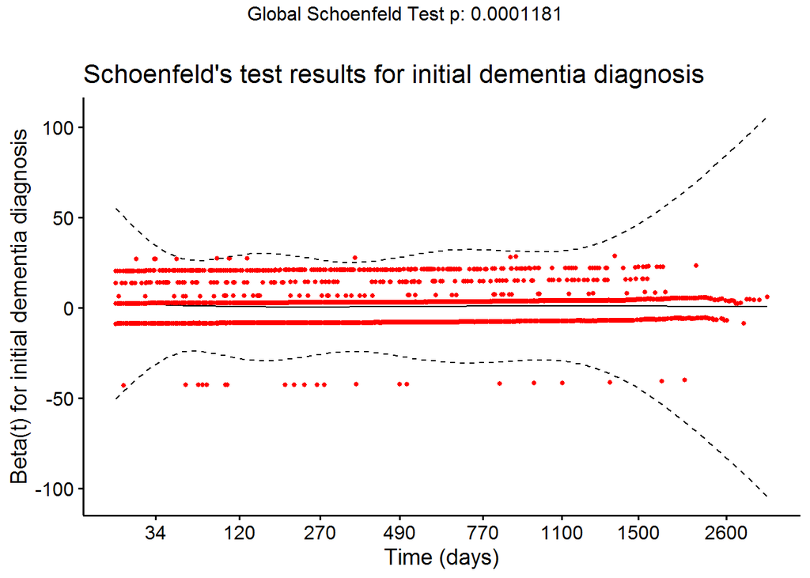

```r
res5 <- cox.zph(cox5)

plot_schoenfeld(res5, "initial dementia diagnosis")
```

```
## [1] "Survival probablity in OxNHS dementia patients"
## [1] "Adjusted for initial dementia diagnosis (time-dependent analysis)"
```

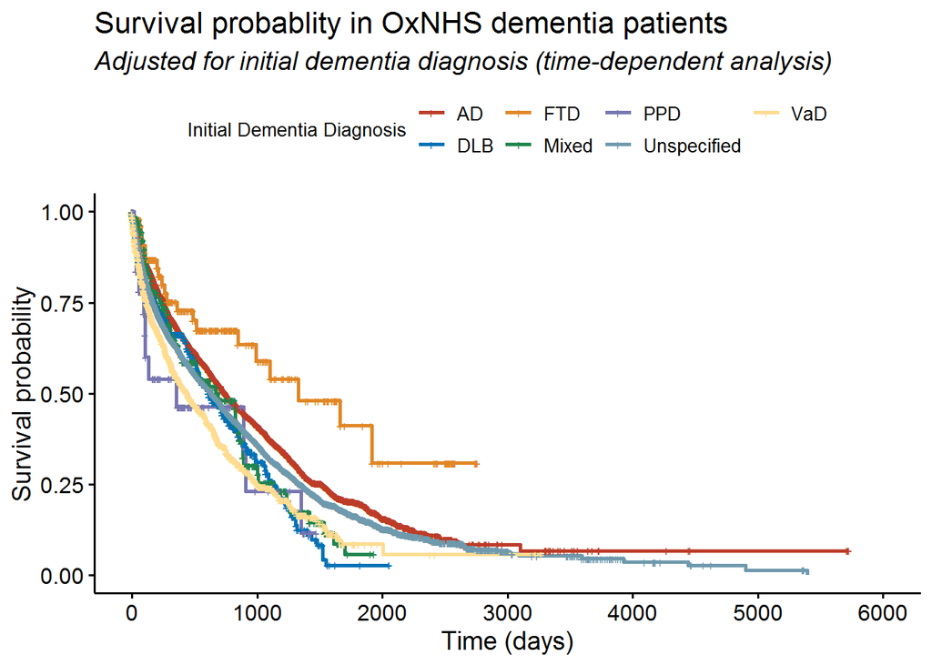

```r
fit5 <- survfit(Surv(time1, time2, event_death) ~ cause_diagper, data = all_df)

plot_surv(fit5, "initial dementia diagnosis", c("AD", "DLB", "FTD", "Mixed", "PPD", "Unspecified", "VaD"))
```

```r
anova(cox5)
```

```
## Analysis of Deviance Table
##  Cox model: response is Surv(time1, time2, event_death)
## Terms added sequentially (first to last)
##
##               loglik  Chisq Df Pr(>|Chi|)
## NULL          -42295
## cause_diagper -42257 75.815  6  2.608e-14 ***
## ---
## Signif. codes:  0 '***' 0.001 '**' 0.01 '*' 0.05 '.' 0.1 ' ' 1
```

**Racial group**

```r
all_df <- all_df %>%
   mutate(Ethnicity_Value = as.factor(Ethnicity_Value)) %>%
   mutate(Ethnicity_Value = relevel(Ethnicity_Value, "White")) #use relevel for ease of interpretation

freq_per_info(all_df$Ethnicity_Value) #reminder of this category's groups
```

```
## var :
##         Frequency   %(NA+)   %(NA-)
## White       41579     70.5     97.1
## NA's        16144     27.4      0.0
## Other         481      0.8      1.1
## Asian         473      0.8      1.1
## Black         296      0.5      0.7
##   Total     58973    100.0    100.0
```

```r
cox6 <- coxph(Surv(time1, time2, event_death) ~ Ethnicity_Value, data = all_df)

summary(cox6)
```

[output not shown]

```r
cox.zph(cox6)
```

```
##                 chisq df      p
## Ethnicity_Value  14.2  3 0.0026
## GLOBAL           14.2  3 0.0026
```

```
## [1] "Schoenfeld's test results for race"
## [1] "Beta(t) for race"
```

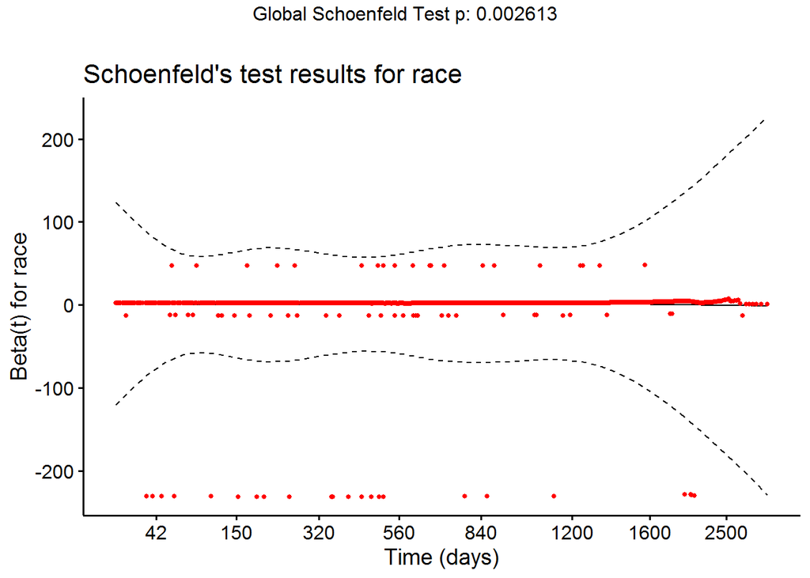

```r
res6 <- cox.zph(cox6)

plot_schoenfeld(res6, "race")
```

```
## [1] "Survival probablity in OxNHS dementia patients"
## [1] "Adjusted for race (time-dependent analysis)"
```

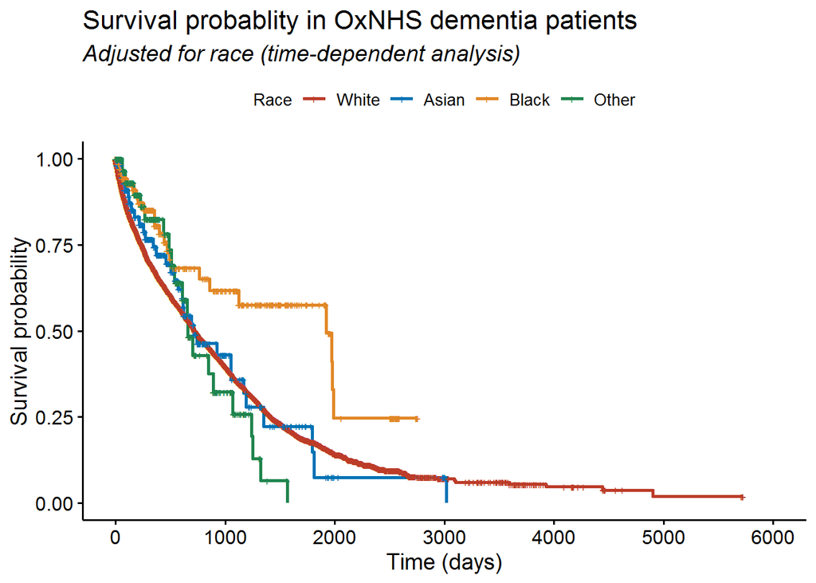

```r
fit6 <- survfit(Surv(time1, time2, event_death) ~ Ethnicity_Value, data = all_df)

plot_surv(fit6, "race", c("White", "Asian", "Black", "Other"))
```

```r
anova(cox6)
```

```
## Analysis of Deviance Table
##  Cox model: response is Surv(time1, time2, event_death)
## Terms added sequentially (first to last)
##
##                 loglik  Chisq Df Pr(>|Chi|)
## NULL            -28378
## Ethnicity_Value -28372 12.704  3   0.005323 **
## ---
## Signif. codes:  0 '***' 0.001 '**' 0.01 '*' 0.05 '.' 0.1 ' ' 1
```

**Dementia medication class**

```r
table(all_df$type_medclass) #reminder of this category's groups
```

```
##
## Any AChEi Mementine
##     33955      7797
```

```r
cox7 <- coxph(Surv(time1, time2, event_death) ~ type_medclass, data = all_df)

summary(cox7)
```

```
## Call:
## coxph(formula = Surv(time1, time2, event_death) ~ type_medclass,
##     data = all_df)
##
##   n= 41752, number of events= 3046
##    (17221 observations deleted due to missingness)
##
##                           coef exp(coef) se(coef)     z Pr(>|z|)
## type_medclassMementine 0.67175   1.95765  0.04747 14.15   <2e-16 ***
## ---
## Signif. codes:  0 '***' 0.001 '**' 0.01 '*' 0.05 '.' 0.1 ' ' 1
##
##                        exp(coef) exp(-coef) lower .95 upper .95
## type_medclassMementine     1.958     0.5108     1.784     2.149
##
## Concordance= 0.538  (se = 0.004 )
## Likelihood ratio test= 173.7  on 1 df,   p=<2e-16
## Wald test            = 200.2  on 1 df,   p=<2e-16
## Score (logrank) test = 207.6  on 1 df,   p=<2e-16
```

```r
cox.zph(cox7)
```

```
##               chisq df    p
## type_medclass  2.27  1 0.13
## GLOBAL         2.27  1 0.13
```

```
## [1] "Schoenfeld's test results for dementia medication class"
## [1] "Beta(t) for dementia medication class"
```

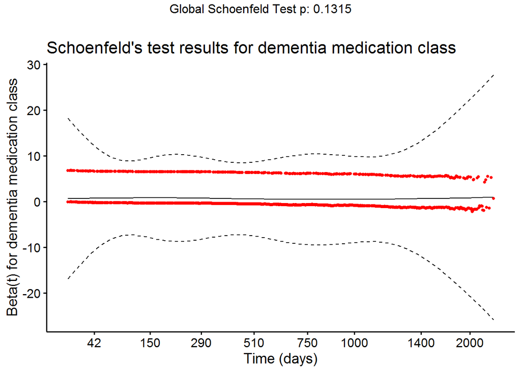

```r
res7 <- cox.zph(cox7)

plot_schoenfeld(res7, "dementia medication class")
```

```
## [1] "Survival probablity in OxNHS dementia patients"
## [1] "Adjusted for dementia medication class (time-dependent analysis)"
```

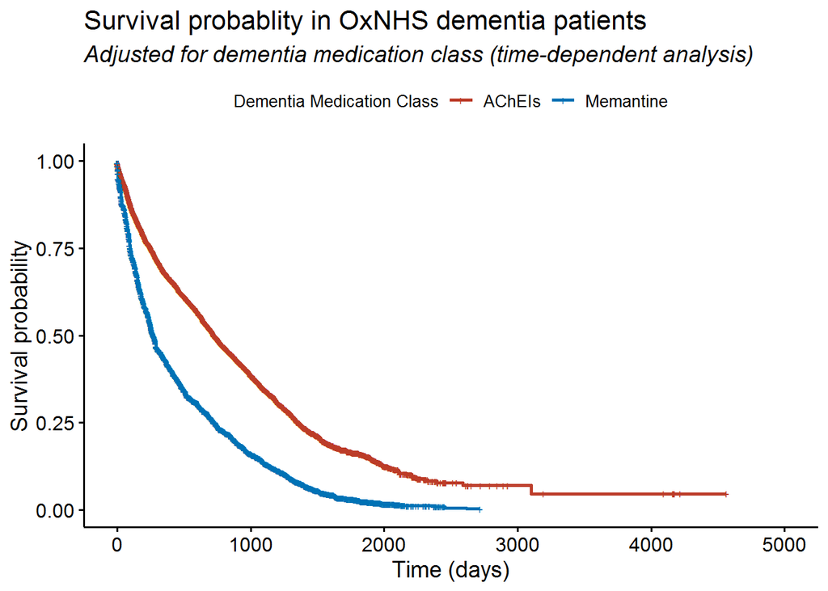

```r
fit7 <- survfit(Surv(time1, time2, event_death) ~ type_medclass, data = all_df)

plot_surv(fit7, "dementia medication class", c("AChEIs", "Memantine"))
```

```r
anova(cox7)
```

```
## Analysis of Deviance Table
##  Cox model: response is Surv(time1, time2, event_death)
## Terms added sequentially (first to last)
##
##               loglik  Chisq Df Pr(>|Chi|)
## NULL          -23010
## type_medclass -22924 173.74  1  < 2.2e-16 ***
## ---
## Signif. codes:  0 '***' 0.001 '**' 0.01 '*' 0.05 '.' 0.1 ' ' 1
```

**Marital status**

```r
freq_per_info(all_df$marital_status)
```

```
## var :
##                    Frequency   %(NA+)   %(NA-)
## <NA>                   22209     37.7      0.0
## Any union              19971     33.9     54.3
## Widowed                12414     21.1     33.8
## Single                  2279      3.9      6.2
## Divorced/Separated      2100      3.6      5.7
##   Total                58973    100.0    100.0
```

```r
cox8 <- coxph(Surv(time1, time2, event_death) ~ marital_status, data = all_df)

summary(cox8)
```

```
## Call:
## coxph(formula = Surv(time1, time2, event_death) ~ marital_status,
##     data = all_df)
##
##   n= 36764, number of events= 2891
##    (22209 observations deleted due to missingness)
##
##                                      coef exp(coef) se(coef)      z Pr(>|z|)
## marital_statusDivorced/Separated -0.29851   0.74192  0.10225 -2.919  0.00351
## marital_statusSingle              0.04868   1.04988  0.07456  0.653  0.51385
## marital_statusWidowed             0.34453   1.41132  0.03956  8.708  < 2e-16
##
## marital_statusDivorced/Separated **
## marital_statusSingle
## marital_statusWidowed            ***
## ---
## Signif. codes:  0 '***' 0.001 '**' 0.01 '*' 0.05 '.' 0.1 ' ' 1
##
##                                  exp(coef) exp(-coef) lower .95 upper .95
## marital_statusDivorced/Separated    0.7419     1.3478    0.6072    0.9066
## marital_statusSingle                1.0499     0.9525    0.9071    1.2151
## marital_statusWidowed               1.4113     0.7086    1.3060    1.5251
##
## Concordance= 0.553  (se = 0.006 )
## Likelihood ratio test= 98.29  on 3 df,   p=<2e-16
## Wald test            = 98.19  on 3 df,   p=<2e-16
## Score (logrank) test = 99.55  on 3 df,   p=<2e-16
```

```r
cox.zph(cox8)
```

```
##                chisq df     p
## marital_status  7.44  3 0.059
## GLOBAL          7.44  3 0.059
```

```
## [1] "Schoenfeld's test results for marital status"
## [1] "Beta(t) for marital status"
```

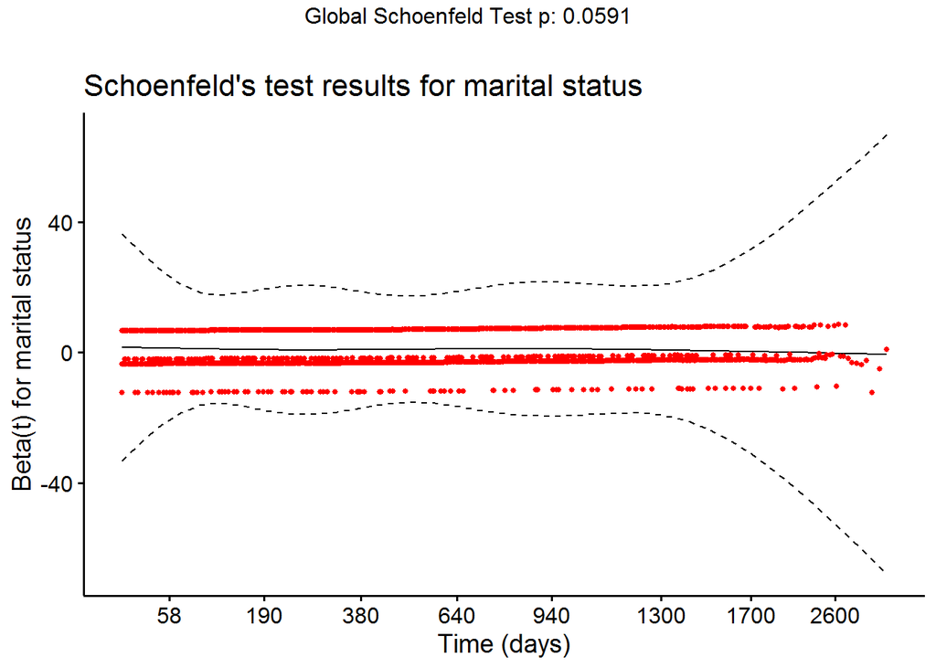

```r
res8 <- cox.zph(cox8)

plot_schoenfeld(res8, "marital status")
```

```
## [1] "Survival probablity in OxNHS dementia patients"
## [1] "Adjusted for marital status (time-dependent analysis)"
```

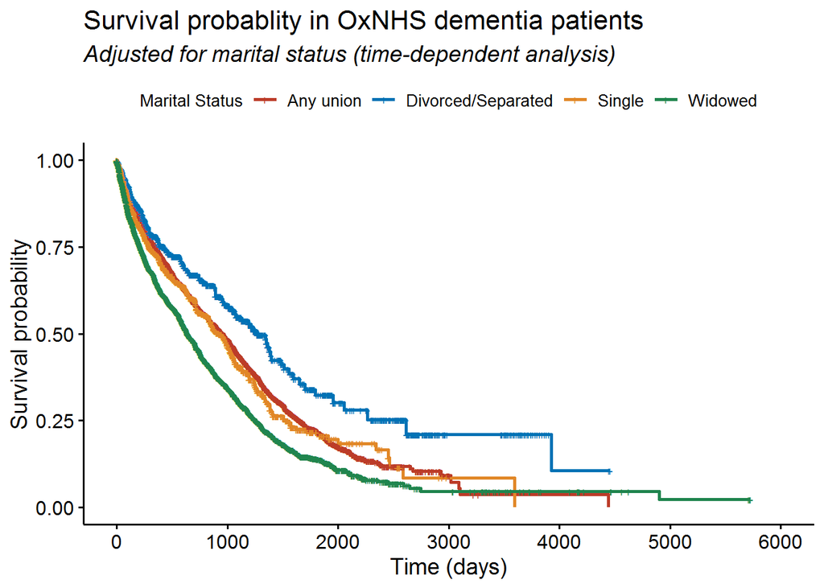

```r
fit8 <- survfit(Surv(time1, time2, event_death) ~ marital_status, data = all_df)

plot_surv(fit8, "marital status", c("Any union", "Divorced/Separated", "Single", "Widowed"))
```

```r
anova(cox8)
```

```
## Analysis of Deviance Table
##  Cox model: response is Surv(time1, time2, event_death)
## Terms added sequentially (first to last)
##
##                loglik  Chisq Df Pr(>|Chi|)
## NULL           -22008
## marital_status -21959 98.294  3  < 2.2e-16 ***
## ---
## Signif. codes:  0 '***' 0.001 '**' 0.01 '*' 0.05 '.' 0.1 ' ' 1
```

**Type of cognitive assessment**

```r
table(all_df$type_cogeval)
```

```
##
##  MMSE  MOCA
## 14088  9709
```

```r
cox9 <- coxph(Surv(time1, time2, event_death) ~ type_cogeval, data = all_df)

summary(cox9)
```

```
## Call:
## coxph(formula = Surv(time1, time2, event_death) ~ type_cogeval,
##     data = all_df)
##
##   n= 23797, number of events= 2309
##    (35176 observations deleted due to missingness)
##
##                      coef exp(coef) se(coef)     z Pr(>|z|)
## type_cogevalMOCA 0.007177  1.007203 0.046187 0.155    0.877
##
##                  exp(coef) exp(-coef) lower .95 upper .95
## type_cogevalMOCA     1.007     0.9928      0.92     1.103
##
## Concordance= 0.503  (se = 0.006 )
## Likelihood ratio test= 0.02  on 1 df,   p=0.9
## Wald test            = 0.02  on 1 df,   p=0.9
## Score (logrank) test = 0.02  on 1 df,   p=0.9
```

```r
cox.zph(cox9)
```

```
##              chisq df   p
## type_cogeval 0.713  1 0.4
## GLOBAL       0.713  1 0.4
```

```
## [1] "Schoenfeld's test results for type of cognitive assessment"
## [1] "Beta(t) for type of cognitive assessment"
```

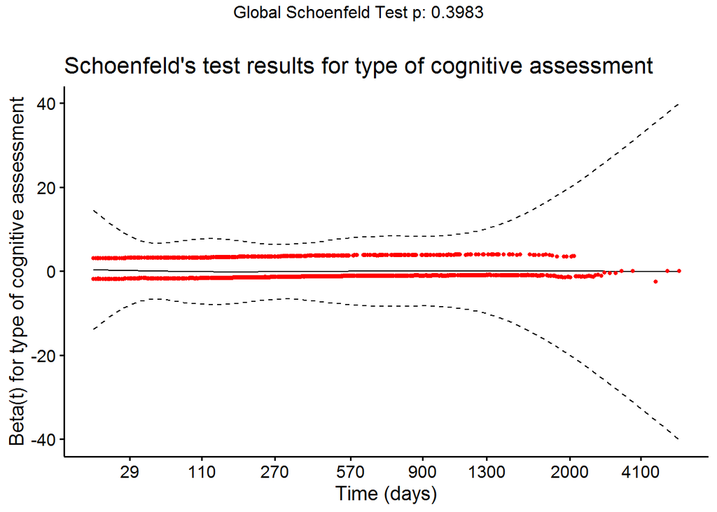

```r
res9 <- cox.zph(cox9)

plot_schoenfeld(res9, "type of cognitive assessment")
```

```
## [1] "Survival probablity in OxNHS dementia patients"
## [1] "Adjusted for type of cognitive assessment (time-dependent analysis)"
```

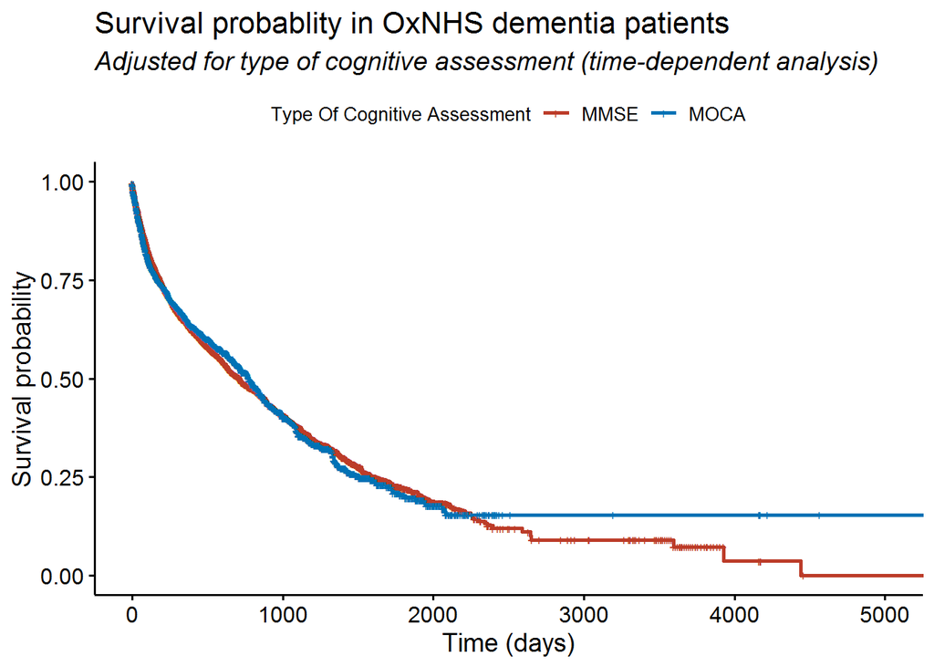

```r
fit9 <- survfit(Surv(time1, time2, event_death) ~ type_cogeval, data = all_df)

plot_surv(fit9, "type of cognitive assessment", c("MMSE", "MOCA"))
```

```r
anova(cox9)
```

```
## Analysis of Deviance Table
##  Cox model: response is Surv(time1, time2, event_death)
## Terms added sequentially (first to last)
##
##              loglik  Chisq Df Pr(>|Chi|)
## NULL         -17559
## type_cogeval -17559 0.0241  1     0.8766
```

**Score in cognitive assessment**

```r
cox10 <- coxph(Surv(time1, time2, event_death) ~ numerator, data = all_df)

summary(cox10)
```

```
## Call:
## coxph(formula = Surv(time1, time2, event_death) ~ numerator,
##     data = all_df)
##
##   n= 23797, number of events= 2309
##    (35176 observations deleted due to missingness)
##
##                coef exp(coef)  se(coef)      z Pr(>|z|)
## numerator -0.044260  0.956705  0.002786 -15.88   <2e-16 ***
## ---
## Signif. codes:  0 '***' 0.001 '**' 0.01 '*' 0.05 '.' 0.1 ' ' 1
##
##           exp(coef) exp(-coef) lower .95 upper .95
## numerator    0.9567      1.045    0.9515    0.9619
##
## Concordance= 0.596  (se = 0.007 )
## Likelihood ratio test= 237.6  on 1 df,   p=<2e-16
## Wald test            = 252.3  on 1 df,   p=<2e-16
## Score (logrank) test = 256.3  on 1 df,   p=<2e-16
```

```r
cox.zph(cox10)
```

```
##           chisq df    p
## numerator  1.27  1 0.26
## GLOBAL     1.27  1 0.26
```

```
## [1] "Schoenfeld's test results for score in cognitive assessment"
## [1] "Beta(t) for score in cognitive assessment"
```

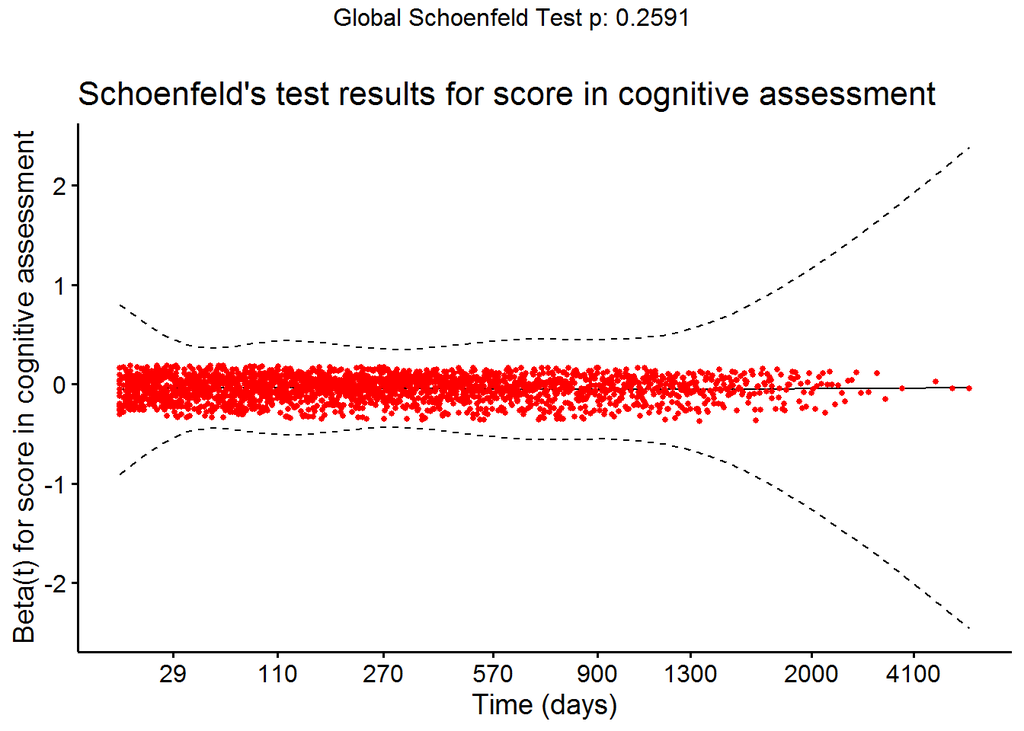

```r
res10 <- cox.zph(cox10)

plot_schoenfeld(res10, "score in cognitive assessment")
```

```r
anova(cox10)
```

```
## Analysis of Deviance Table
##  Cox model: response is Surv(time1, time2, event_death)
## Terms added sequentially (first to last)
##
##           loglik  Chisq Df Pr(>|Chi|)
## NULL      -17559
## numerator -17440 237.55  1  < 2.2e-16 ***
## ---
## Signif. codes:  0 '***' 0.001 '**' 0.01 '*' 0.05 '.' 0.1 ' ' 1
```

**Type of chronic medication**

```r
freq_per_info(all_df$medother_grouped)
```

```
## var :
##                Frequency   %(NA+)   %(NA-)
## <NA>               41573     70.5      0.0
## Antipsychotics      6794     11.5     39.0
## SSRIs               4028      6.8     23.1
## Trazodone           3073      5.2     17.7
## TeCAs               2010      3.4     11.6
## Insulin              553      0.9      3.2
## SNRIs                526      0.9      3.0
## TCAs                 416      0.7      2.4
##   Total            58973    100.0    100.0
```

```r
cox11 <- coxph(Surv(time1, time2, event_death) ~ medother_grouped, data = all_df)

summary(cox11)
```

```
## Call:
## coxph(formula = Surv(time1, time2, event_death) ~ medother_grouped,
##     data = all_df)
##
##   n= 17400, number of events= 1150
##    (41573 observations deleted due to missingness)
##
##                               coef exp(coef) se(coef)      z Pr(>|z|)
## medother_groupedInsulin   -0.36536   0.69395  0.16737 -2.183 0.029039 *
## medother_groupedSNRIs     -0.48630   0.61490  0.20749 -2.344 0.019096 *
## medother_groupedSSRIs     -0.29726   0.74285  0.07825 -3.799 0.000145 ***
## medother_groupedTCAs      -0.46002   0.63127  0.18523 -2.483 0.013010 *
## medother_groupedTeCAs     -0.23814   0.78809  0.10044 -2.371 0.017740 *
## medother_groupedTrazodone  0.21533   1.24027  0.08316  2.589 0.009617 **
## ---
## Signif. codes:  0 '***' 0.001 '**' 0.01 '*' 0.05 '.' 0.1 ' ' 1
##
##                           exp(coef) exp(-coef) lower .95 upper .95
## medother_groupedInsulin      0.6939     1.4410    0.4999    0.9634
## medother_groupedSNRIs        0.6149     1.6263    0.4094    0.9235
## medother_groupedSSRIs        0.7428     1.3462    0.6372    0.8660
## medother_groupedTCAs         0.6313     1.5841    0.4391    0.9076
## medother_groupedTeCAs        0.7881     1.2689    0.6473    0.9596
## medother_groupedTrazodone    1.2403     0.8063    1.0537    1.4598
##
## Concordance= 0.56  (se = 0.01 )
## Likelihood ratio test= 53.28  on 6 df,   p=1e-09
## Wald test            = 54.15  on 6 df,   p=7e-10
## Score (logrank) test = 55.15  on 6 df,   p=4e-10
```

```r
cox.zph(cox11)
```

```
##                  chisq df    p
## medother_grouped  9.63  6 0.14
## GLOBAL            9.63  6 0.14
```

```
## [1] "Schoenfeld's test results for type of chronic medication"
## [1] "Beta(t) for type of chronic medication"
```

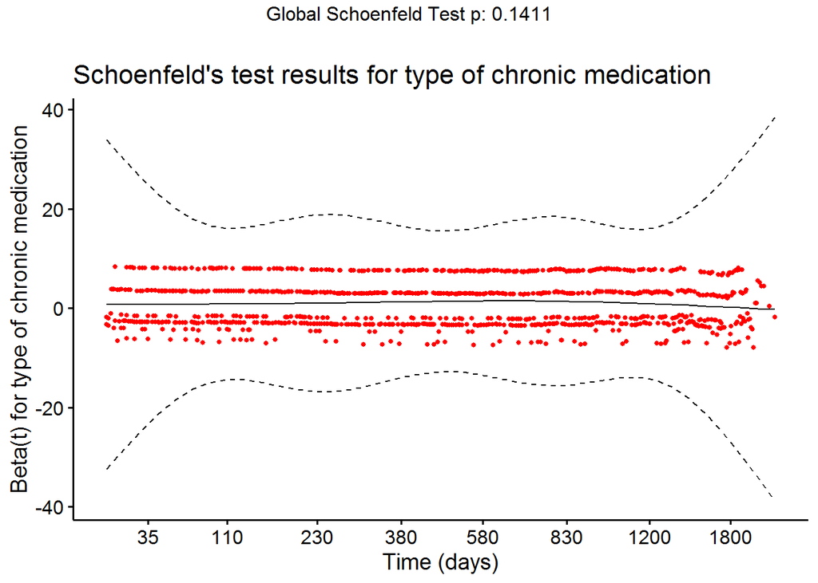

```r
res11 <- cox.zph(cox11)

plot_schoenfeld(res11, "type of chronic medication")
```

```
## [1] "Survival probablity in OxNHS dementia patients"
## [1] "Adjusted for type of chronic medication (time-dependent analysis)"
```

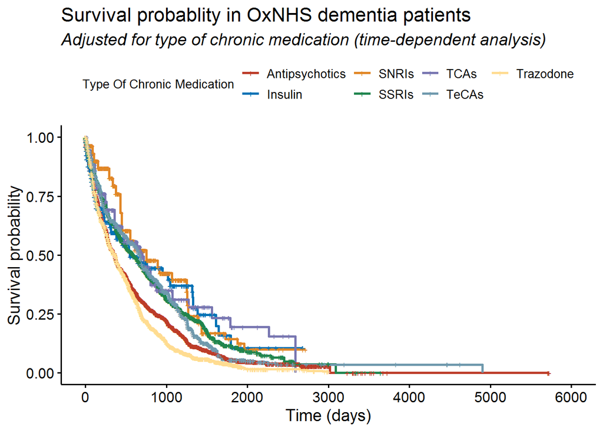

```r
fit11 <- survfit(Surv(time1, time2, event_death) ~ medother_grouped, data = all_df)

plot_surv(fit11, "type of chronic medication", c("Antipsychotics", "Insulin", "SNRIs", "SSRIs",
                                                 "TCAs", "TeCAs", "Trazodone"))
```

```r
anova(cox11)
```

```
## Analysis of Deviance Table
##  Cox model: response is Surv(time1, time2, event_death)
## Terms added sequentially (first to last)
##
##                   loglik  Chisq Df Pr(>|Chi|)
## NULL             -7099.9
## medother_grouped -7073.3 53.282  6  1.029e-09 ***
## ---
## Signif. codes:  0 '***' 0.001 '**' 0.01 '*' 0.05 '.' 0.1 ' ' 1
```

##### **Multivariate models**

**Gender and age of entry**

```r
cox_m0 <- coxph(Surv(time1, time2, event_death) ~ Gender_Value + age_entry, data = all_df) #fit model

summary(cox_m0) #print results
```

```
## Call:
## coxph(formula = Surv(time1, time2, event_death) ~ Gender_Value +
##     age_entry, data = all_df)
##
##   n= 58973, number of events= 5145
##
##                     coef exp(coef) se(coef)      z Pr(>|z|)
## Gender_ValueMale 0.20313   1.22523  0.02874  7.068 1.57e-12 ***
## age_entry        0.07651   1.07952  0.00212 36.086  < 2e-16 ***
## ---
## Signif. codes:  0 '***' 0.001 '**' 0.01 '*' 0.05 '.' 0.1 ' ' 1
##
##                  exp(coef) exp(-coef) lower .95 upper .95
## Gender_ValueMale     1.225     0.8162     1.158     1.296
## age_entry            1.080     0.9263     1.075     1.084
##
## Concordance= 0.657  (se = 0.004 )
## Likelihood ratio test= 1438  on 2 df,   p=<2e-16
## Wald test            = 1304  on 2 df,   p=<2e-16
## Score (logrank) test = 1318  on 2 df,   p=<2e-16
```

```r
cox.zph(cox_m0) #print Schoenfeld's test results
```

```
##               chisq df       p
## Gender_Value  0.204  1 0.65130
## age_entry    16.280  1 5.5e-05
## GLOBAL       16.307  2 0.00029
```

```
## $`1`
```

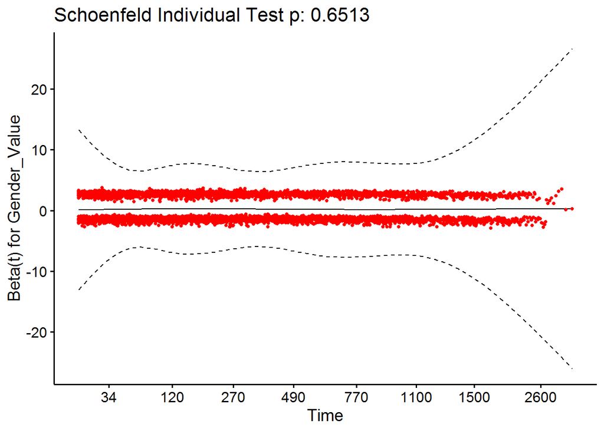

```r
resm0 <- cox.zph(cox_m0) #store Schoenfeld's test results

ggcoxzph(resm0)[1] #plot Schoenfeld's test for first variable (Gender_Value)
```

```
## $`2`
```

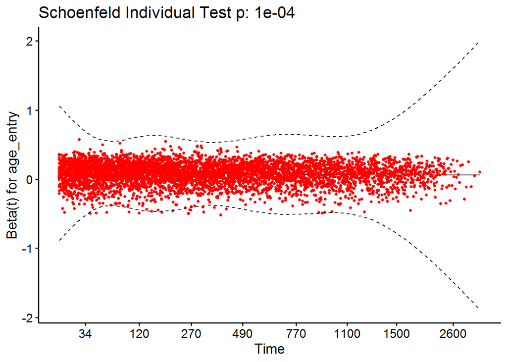

```r
ggcoxzph(resm0)[2] #plot Schoenfeld's test for second variable (age_entry)
```

```r
anova(cox_m0) #ANOVA log likelihood test to determine whether fitted model is significantly better than a no-model solution
```

```
## Analysis of Deviance Table
##  Cox model: response is Surv(time1, time2, event_death)
## Terms added sequentially (first to last)
##
##              loglik     Chisq Df Pr(>|Chi|)
## NULL         -42295
## Gender_Value -42294    2.7536  1    0.09703 .
## age_entry    -41577 1434.7556  1    < 2e-16 ***
## ---
## Signif. codes:  0 '***' 0.001 '**' 0.01 '*' 0.05 '.' 0.1 ' ' 1
```

Repeat for all other multivaraite models.

**Gender and age of observation**

```r
cox_m1 <- coxph(Surv(time1, time2, event_death) ~ Gender_Value + age_obsv, data = all_df)

summary(cox_m1)
```

```
## Call:
## coxph(formula = Surv(time1, time2, event_death) ~ Gender_Value +
##     age_obsv, data = all_df)
##
##   n= 58973, number of events= 5145
##
##                     coef exp(coef) se(coef)      z Pr(>|z|)
## Gender_ValueMale 0.21182   1.23592  0.02874  7.371  1.7e-13 ***
## age_obsv         0.08172   1.08515  0.00213 38.357  < 2e-16 ***
## ---
## Signif. codes:  0 '***' 0.001 '**' 0.01 '*' 0.05 '.' 0.1 ' ' 1
##
##                  exp(coef) exp(-coef) lower .95 upper .95
## Gender_ValueMale     1.236     0.8091     1.168     1.308
## age_obsv             1.085     0.9215     1.081     1.090
##
## Concordance= 0.661  (se = 0.004 )
## Likelihood ratio test= 1638  on 2 df,   p=<2e-16
## Wald test            = 1473  on 2 df,   p=<2e-16
## Score (logrank) test = 1488  on 2 df,   p=<2e-16
```

```r
cox.zph(cox_m1)
```

```
##               chisq df    p
## Gender_Value 0.0991  1 0.75
## age_obsv     2.4347  1 0.12
## GLOBAL       2.4424  2 0.29
```

```r
resm1 <- cox.zph(cox_m1)

ggcoxzph(resm1)[1]
```

```
## $`1`
```

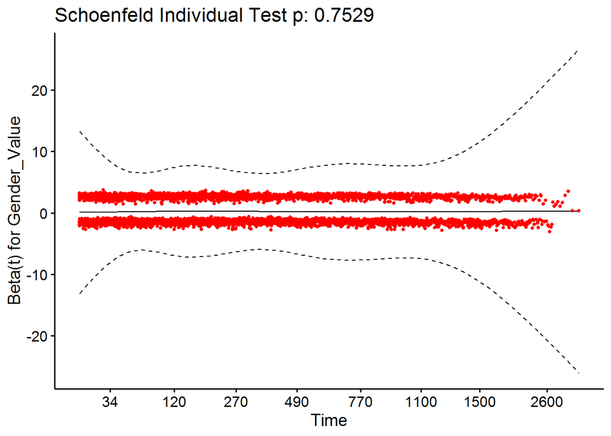

```r
ggcoxzph(resm1)[2]
```

```
## $`2`
```

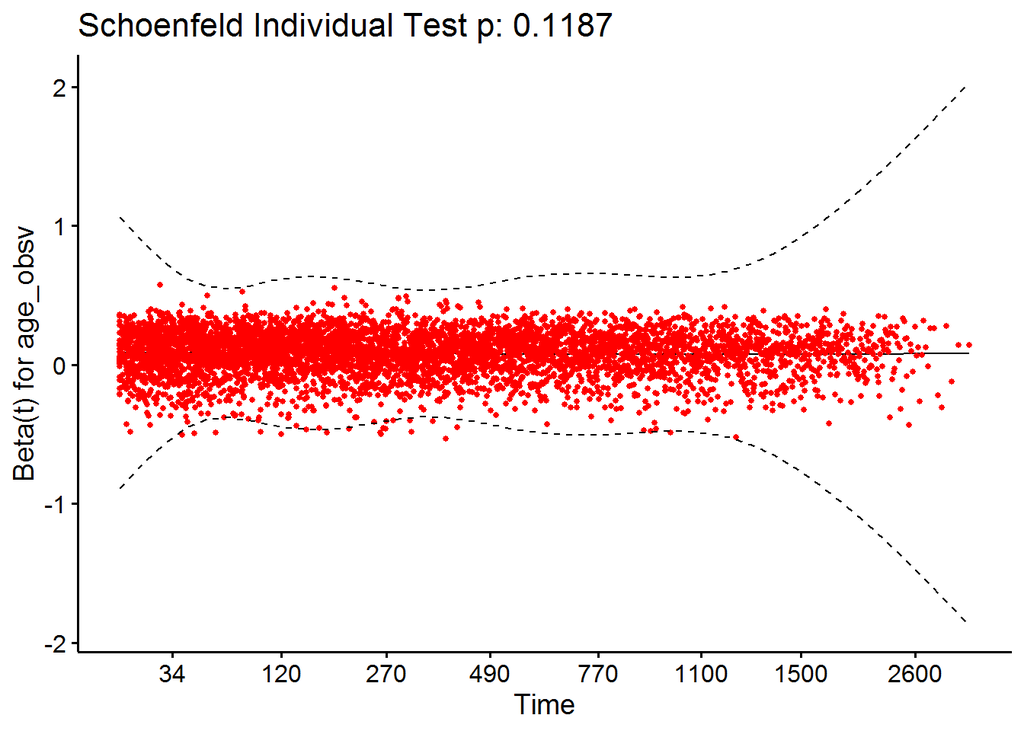

```r
anova(cox_m1)
```

```
## Analysis of Deviance Table
##  Cox model: response is Surv(time1, time2, event_death)
## Terms added sequentially (first to last)
##
##              loglik     Chisq Df Pr(>|Chi|)
## NULL         -42295
## Gender_Value -42294    2.7536  1    0.09703 .
## age_obsv     -41476 1635.5929  1    < 2e-16 ***
## ---
## Signif. codes:  0 '***' 0.001 '**' 0.01 '*' 0.05 '.' 0.1 ' ' 1
```

We plotted models’ results as forest plots for models that met the proportionality assumption and for which all covariates were significant.

*Forest plot*

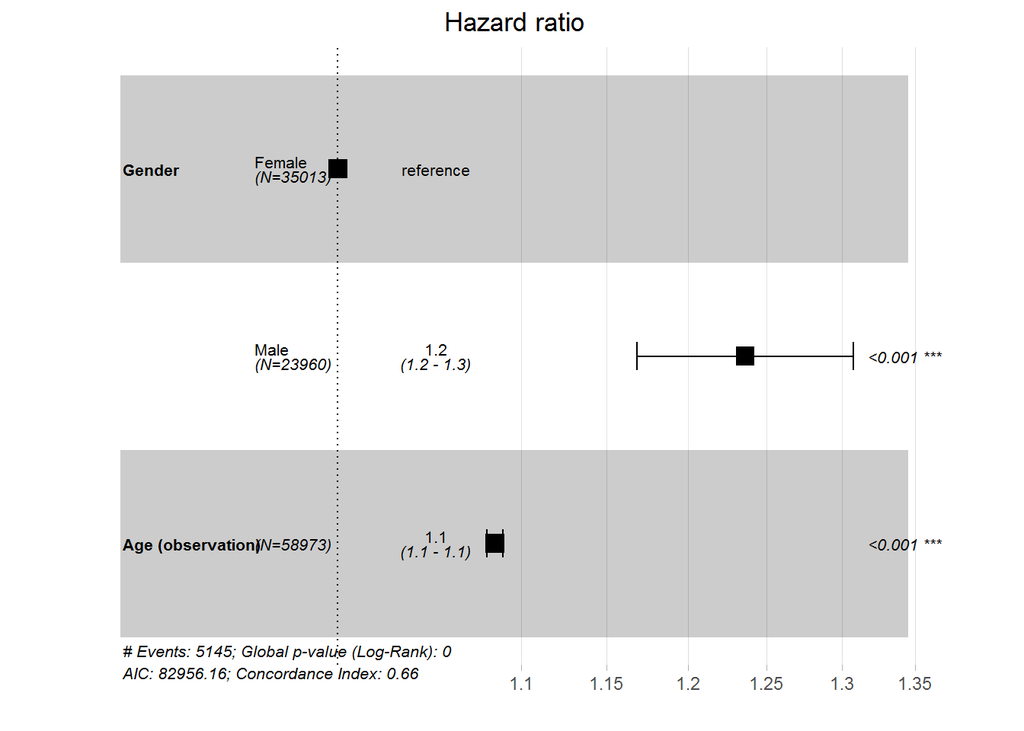

```r
#the steps below apply to all forest plots created henceforward

#subset data for forest plot's aesthetics

forest_df1 <- all_df %>%
  transmute(time1, #extract survival object terms
            time2,
            event_death,
            Gender = factor(Gender_Value), #extract covariates of interest and rename
            `Age (observation)` = age_obsv) %>%
  mutate(Gender = relevel(Gender, ref = "Female")) #relevel when necessary so hazard ratios use consistent reference groups

#fit model again, but use new variable names for aesthetics purposes

new1 <- coxph(Surv(time1, time2, event_death) ~ Gender + `Age (observation)`, data = forest_df1)

#print forest plot

ggforest(new1,
         cpositions = c(0.003, 0.17, 0.4)) #cpositions controls positions of text in plot
```

**Gender and age of diagnosis**

```r
cox_m2 <- coxph(Surv(time1, time2, event_death) ~ Gender_Value + age_diag, data = all_df)

summary(cox_m2)
```

```
## Call:
## coxph(formula = Surv(time1, time2, event_death) ~ Gender_Value +
##     age_diag, data = all_df)
##
##   n= 58973, number of events= 5145
##
##                      coef exp(coef) se(coef)      z Pr(>|z|)
## Gender_ValueMale 0.202008  1.223858 0.028761  7.024 2.16e-12 ***
## age_diag         0.071606  1.074232 0.002068 34.622  < 2e-16 ***
## ---
## Signif. codes:  0 '***' 0.001 '**' 0.01 '*' 0.05 '.' 0.1 ' ' 1
##
##                  exp(coef) exp(-coef) lower .95 upper .95
## Gender_ValueMale     1.224     0.8171     1.157     1.295
## age_diag             1.074     0.9309     1.070     1.079
##
## Concordance= 0.652  (se = 0.005 )
## Likelihood ratio test= 1314  on 2 df,   p=<2e-16
## Wald test            = 1201  on 2 df,   p=<2e-16
## Score (logrank) test = 1212  on 2 df,   p=<2e-16
```

```r
cox.zph(cox_m2)
```

```
##               chisq df       p
## Gender_Value  0.627  1    0.43
## age_diag     23.517  1 1.2e-06
## GLOBAL       23.518  2 7.8e-06
```

```r
resm2 <- cox.zph(cox_m2)

ggcoxzph(resm2)[1]
```

```
## $`1`
```

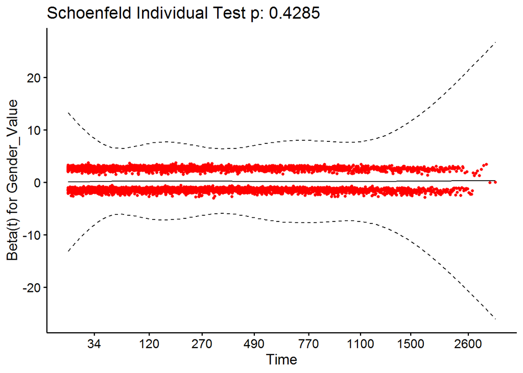

```r
ggcoxzph(resm2)[2]
```

```
## $`2`
```

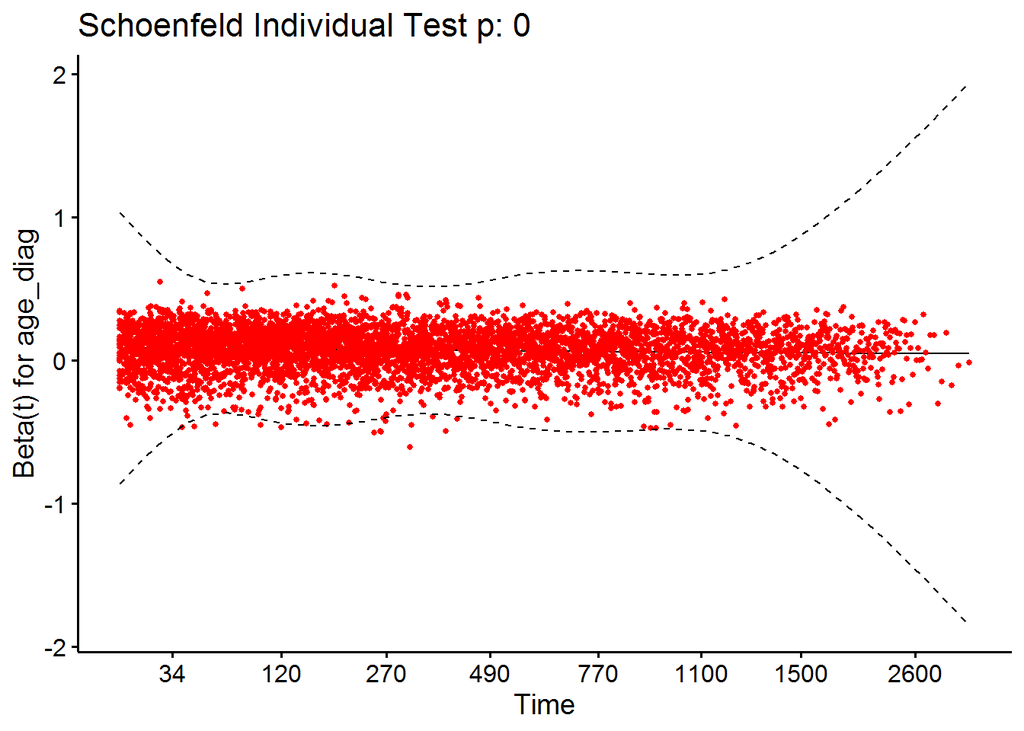

```r
anova(cox_m2)
```

```
## Analysis of Deviance Table
##  Cox model: response is Surv(time1, time2, event_death)
## Terms added sequentially (first to last)
##
##              loglik     Chisq Df Pr(>|Chi|)
## NULL         -42295
## Gender_Value -42294    2.7536  1    0.09703 .
## age_diag     -41638 1311.3254  1    < 2e-16 ***
## ---
## Signif. codes:  0 '***' 0.001 '**' 0.01 '*' 0.05 '.' 0.1 ' ' 1
```

**Gender and dementia medication exposure**

```r
cox_m3 <- coxph(Surv(time1, time2, event_death) ~ Gender_Value + med_exposure, data = all_df)

summary(cox_m3)
```

```
## Call:
## coxph(formula = Surv(time1, time2, event_death) ~ Gender_Value +
##     med_exposure, data = all_df)
##
##   n= 58973, number of events= 5145
##
##                          coef exp(coef) se(coef)     z Pr(>|z|)
## Gender_ValueMale      0.04748   1.04862  0.02837 1.673   0.0943 .
## med_exposureunexposed 0.06317   1.06521  0.02914 2.168   0.0302 *
## ---
## Signif. codes:  0 '***' 0.001 '**' 0.01 '*' 0.05 '.' 0.1 ' ' 1
##
##                       exp(coef) exp(-coef) lower .95 upper .95
## Gender_ValueMale          1.049     0.9536    0.9919     1.109
## med_exposureunexposed     1.065     0.9388    1.0061     1.128
##
## Concordance= 0.536  (se = 0.005 )
## Likelihood ratio test= 7.42  on 2 df,   p=0.02
## Wald test            = 7.46  on 2 df,   p=0.02
## Score (logrank) test = 7.46  on 2 df,   p=0.02
```

```r
cox.zph(cox_m3)
```

```
##               chisq df      p
## Gender_Value   0.49  1   0.48
## med_exposure 183.57  1 <2e-16
## GLOBAL       183.98  2 <2e-16
```

```r
resm3 <- cox.zph(cox_m3)

ggcoxzph(resm3)[1]
```

```
## $`1`
```

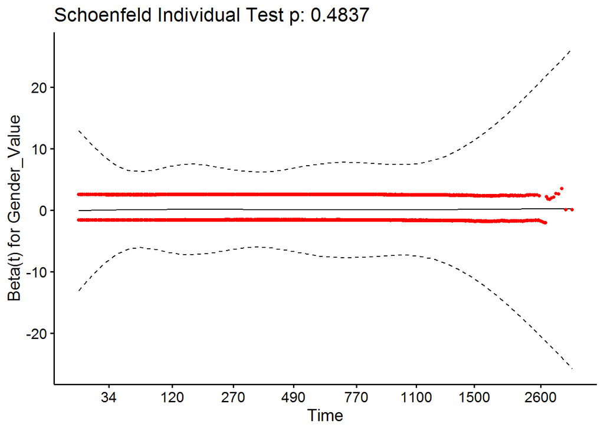

```r
ggcoxzph(resm3)[2]
```

```
## $`2`
```

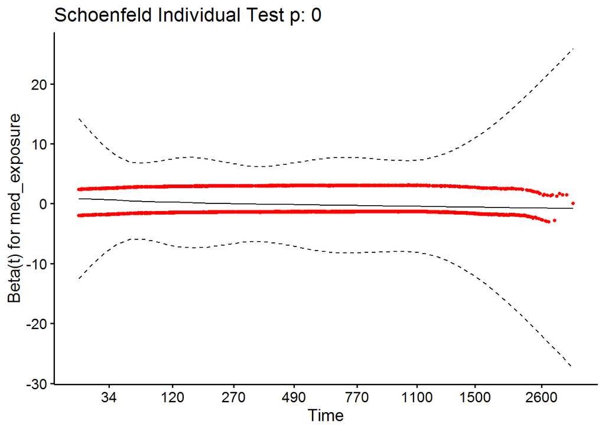

```r
anova(cox_m3)
```

```
## Analysis of Deviance Table
##  Cox model: response is Surv(time1, time2, event_death)
## Terms added sequentially (first to last)
##
##              loglik  Chisq Df Pr(>|Chi|)
## NULL         -42295
## Gender_Value -42294 2.7536  1    0.09703 .
## med_exposure -42292 4.6712  1    0.03067 *
## ---
## Signif. codes:  0 '***' 0.001 '**' 0.01 '*' 0.05 '.' 0.1 ' ' 1
```

**Gender and initial diagnosis**

```r
cox_m4 <- coxph(Surv(time1, time2, event_death) ~ Gender_Value + cause_diagper, data = all_df)

summary(cox_m4)
```

```
## Call:
## coxph(formula = Surv(time1, time2, event_death) ~ Gender_Value +
##     cause_diagper, data = all_df)
##
##   n= 58973, number of events= 5145
##
##                              coef exp(coef) se(coef)      z Pr(>|z|)
## Gender_ValueMale          0.03978   1.04058  0.02842  1.400  0.16153
## cause_diagperDLB          0.32692   1.38670  0.09552  3.423  0.00062 ***
## cause_diagperFTD         -0.50804   0.60167  0.21967 -2.313  0.02074 *
## cause_diagperMixedADVaD   0.21610   1.24122  0.13843  1.561  0.11852
## cause_diagperPPD          0.53356   1.70499  0.28982  1.841  0.06562 .
## cause_diagperUnspecified  0.16368   1.17783  0.03095  5.289 1.23e-07 ***
## cause_diagperVaD          0.42935   1.53626  0.06063  7.082 1.42e-12 ***
## ---
## Signif. codes:  0 '***' 0.001 '**' 0.01 '*' 0.05 '.' 0.1 ' ' 1
##
##                          exp(coef) exp(-coef) lower .95 upper .95
## Gender_ValueMale            1.0406     0.9610    0.9842    1.1002
## cause_diagperDLB            1.3867     0.7211    1.1499    1.6722
## cause_diagperFTD            0.6017     1.6620    0.3912    0.9254
## cause_diagperMixedADVaD     1.2412     0.8057    0.9463    1.6281
## cause_diagperPPD            1.7050     0.5865    0.9661    3.0090
## cause_diagperUnspecified    1.1778     0.8490    1.1085    1.2515
## cause_diagperVaD            1.5363     0.6509    1.3641    1.7301
##
## Concordance= 0.535  (se = 0.005 )
## Likelihood ratio test= 77.77  on 7 df,   p=4e-14
## Wald test            = 77.86  on 7 df,   p=4e-14
## Score (logrank) test = 78.72  on 7 df,   p=3e-14
```

```r
cox.zph(cox_m4)
```

```
##                chisq df       p
## Gender_Value   0.482  1 0.48755
## cause_diagper 27.507  6 0.00012
## GLOBAL        27.959  7 0.00022
```

```r
resm4 <- cox.zph(cox_m4)

ggcoxzph(resm4)[1]
```

```
## $`1`
```

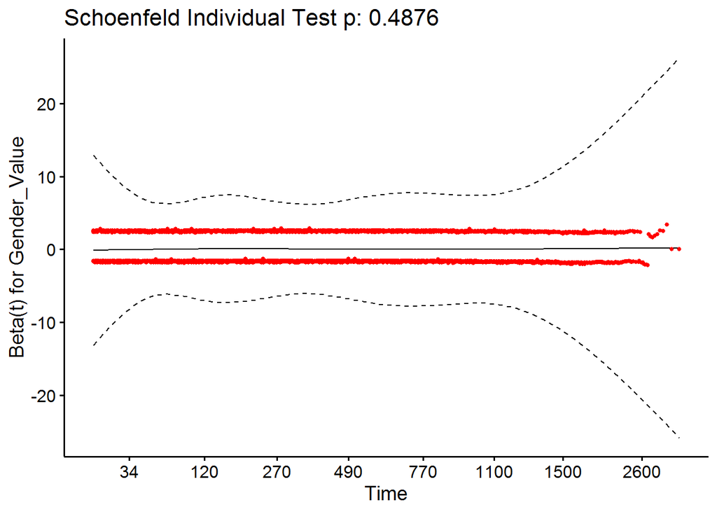

```r
ggcoxzph(resm4)[2]
```

```
## $`2`
```

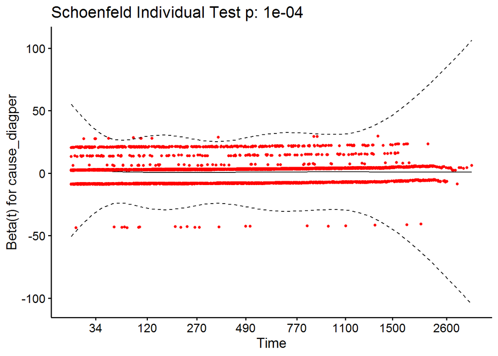

```r
anova(cox_m4)
```

```
## Analysis of Deviance Table
##  Cox model: response is Surv(time1, time2, event_death)
## Terms added sequentially (first to last)
##
##               loglik   Chisq Df Pr(>|Chi|)
## NULL          -42295
## Gender_Value  -42294  2.7536  1    0.09703 .
## cause_diagper -42256 75.0165  6  3.808e-14 ***
## ---
## Signif. codes:  0 '***' 0.001 '**' 0.01 '*' 0.05 '.' 0.1 ' ' 1
```

**Gender, age at observation, and age of entry**

```r
cox_m5 <- coxph(Surv(time1, time2, event_death) ~ Gender_Value + age_obsv + age_entry, data = all_df)

summary(cox_m5)
```

```
## Call:
## coxph(formula = Surv(time1, time2, event_death) ~ Gender_Value +
##     age_obsv + age_entry, data = all_df)
##
##   n= 58973, number of events= 5145
##
##                      coef exp(coef) se(coef)       z Pr(>|z|)
## Gender_ValueMale  0.18670   1.20527  0.02876   6.492 8.45e-11 ***
## age_obsv          0.94727   2.57867  0.03606  26.272  < 2e-16 ***
## age_entry        -0.87101   0.41853  0.03611 -24.124  < 2e-16 ***
## ---
## Signif. codes:  0 '***' 0.001 '**' 0.01 '*' 0.05 '.' 0.1 ' ' 1
##
##                  exp(coef) exp(-coef) lower .95 upper .95
## Gender_ValueMale    1.2053     0.8297    1.1392    1.2751
## age_obsv            2.5787     0.3878    2.4027    2.7675
## age_entry           0.4185     2.3893    0.3899    0.4492
##
## Concordance= 0.684  (se = 0.004 )
## Likelihood ratio test= 2479  on 3 df,   p=<2e-16
## Wald test            = 1952  on 3 df,   p=<2e-16
## Score (logrank) test = 2022  on 3 df,   p=<2e-16
```

```r
cox.zph(cox_m5)
```

```
##                 chisq df       p
## Gender_Value   0.0956  1    0.76
## age_obsv      21.7635  1 3.1e-06
## age_entry     15.6254  1 7.7e-05
## GLOBAL       310.9803  3 < 2e-16
```

```r
resm5 <- cox.zph(cox_m5)

ggcoxzph(resm5)[1]
```

```
## $`1`
```

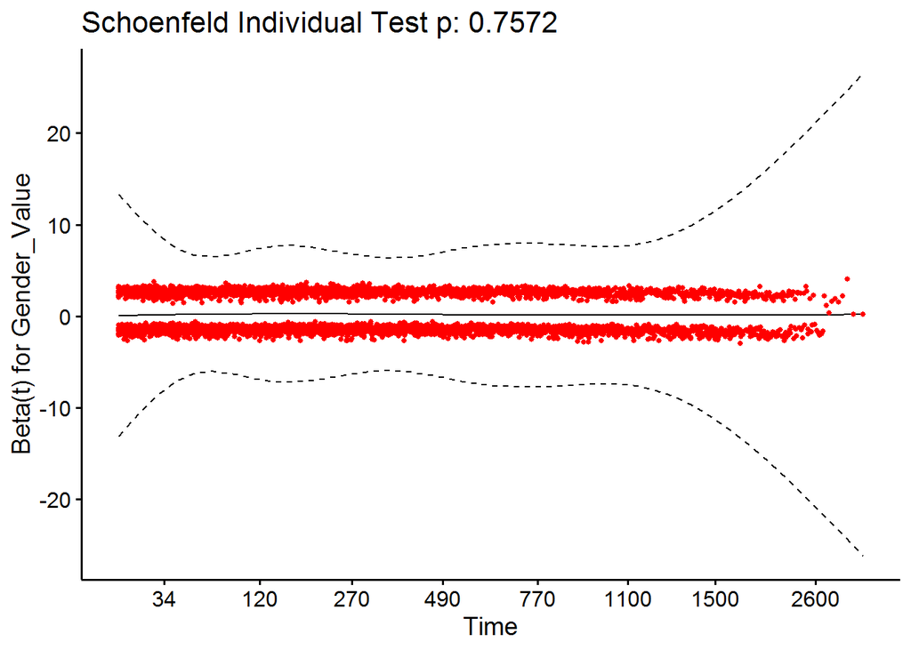